# Hackathon and Review

This session is designed to help you prepare for the hackathon. We’ll start with Q&A about the tasks, then review the some of the skills you might need.

# Part 1: Hackathon Q&A

# Part 2: Skills Review

## Data wrangling with dplyr

The dplyr verbs you’ll use constantly:

```r
# select: choose columns
penguins |> select(species, bill_length_mm, body_mass_g)

# filter: choose rows based on conditions
penguins |> filter(species == "Adelie", year == 2007)

# mutate: create or modify columns
penguins |> mutate(body_mass_kg = body_mass_g / 1000)

# group_by + summarize: aggregate data
penguins |>
  group_by(species) |>
  summarize(
    mean_mass = mean(body_mass_g, na.rm = TRUE),
    n = n()
  )

# arrange: sort rows
penguins |> arrange(desc(body_mass_g))
```

Other useful functions:

```r
# count: shortcut for group_by + summarize(n = n())
penguins |> count(species, island)

# case_when: vectorized if-else for creating categories
penguins |>
  mutate(
    size = case_when(
      body_mass_g < 3500 ~ "small",
      body_mass_g < 5000 ~ "medium",
      TRUE ~ "large"
    )
  )

# across: apply a function to multiple columns
penguins |>
  summarize(across(where(is.numeric), mean, na.rm = TRUE))
```

Reshaping: pivot_longer – turn many columns into key-value pairs. pivot_wider – spread key-value pairs into multiple columns.

```r
# pivot_longer
penguins_long <- penguins |>
  select(species, starts_with("bill_")) |>
  mutate(id = row_number()) |>
  pivot_longer(
    cols = starts_with("bill_"),
    names_to = "measure",
    values_to = "value"
  )
head(penguins_long)
```

```
## # A tibble: 6 × 4
##   species    id measure        value
##   <fct>   <int> <chr>          <dbl>
## 1 Adelie      1 bill_length_mm  39.1
## 2 Adelie      1 bill_depth_mm   18.7
## 3 Adelie      2 bill_length_mm  39.5
## 4 Adelie      2 bill_depth_mm   17.4
## 5 Adelie      3 bill_length_mm  40.3
## 6 Adelie      3 bill_depth_mm   18
```

```r
# pivot_wider
penguins_long |>
  pivot_wider(
    names_from = measure,
    values_from = value
  ) |>
  head()
```

```
## # A tibble: 6 × 4
##   species    id bill_length_mm bill_depth_mm
##   <fct>   <int>          <dbl>         <dbl>
## 1 Adelie      1           39.1          18.7
## 2 Adelie      2           39.5          17.4
## 3 Adelie      3           40.3          18
## 4 Adelie      4           NA            NA
## 5 Adelie      5           36.7          19.3
## 6 Adelie      6           39.3          20.6
```

## Writing functions

Recall the basic structure of a function:

```r
function_name <- function(arguments) {
  # body: what the function does
  # last expression is returned (or use return())
}
```

A simple example:

```r
calculate_stats <- function(x) {
  c(
    mean = mean(x, na.rm = TRUE),
    sd = sd(x, na.rm = TRUE),
    n = length(x)
  )
}

calculate_stats(penguins$bill_length_mm)
```

```
##       mean         sd          n
##  43.921930   5.459584 344.000000
```

### Input validation

Good functions check their inputs and fail with helpful messages:

```
my_function <- function(data, var_name) {

  # Check data type
  if (!is.data.frame(data)) {
    stop("'data' must be a data frame")
  }

  # Check if column exists
  if (!var_name %in% names(data)) {
    stop(paste("Column", var_name, "not found in data"))
  }

  # Check if variable is the right type

  # ... rest of function
}
```

### Passing column names to functions

Two main approaches in the tidyverse:

**Approach 1: Column name as string + `.data[[]]`**

```r
group_mean <- function(data, group_col, value_col) {
  data |>
    group_by(.data[[group_col]]) |>
    summarize(mean_value = mean(.data[[value_col]], na.rm = TRUE))
}

group_mean(penguins, "species", "bill_length_mm")
```

```
## # A tibble: 3 × 2
##   species   mean_value
##   <fct>          <dbl>
## 1 Adelie          38.8
## 2 Chinstrap       48.8
## 3 Gentoo          47.5
```

**Approach 2: Bare column name + `{{ }}`** (tidy evaluation)

```r
group_mean2 <- function(data, group_col, value_col) {
  data |>
    group_by({{ group_col }}) |>
    summarize(mean_value = mean({{ value_col }}, na.rm = TRUE))
}

group_mean2(penguins, species, bill_length_mm)
```

```
## # A tibble: 3 × 2
##   species   mean_value
##   <fct>          <dbl>
## 1 Adelie          38.8
## 2 Chinstrap       48.8
## 3 Gentoo          47.5
```

## Iteration with purrr

The `map()` family applies a function to each element of a list or vector:

- `map()` returns a list
- `map_dbl()` returns a numeric vector
- `map_chr()` returns a character vector
- `map_dfr()` returns a data frame (row-binding results)

Three ways to pass functions to `map()`:

```r
# 1. Named function
map(penguins |> select(where(is.numeric)), mean, na.rm = TRUE)

# 2. Anonymous function
map(penguins |> select(where(is.numeric)), \(x) mean(x, na.rm = TRUE))

# 3. Formula shorthand (older style)
map(penguins |> select(where(is.numeric)), ~ mean(.x, na.rm = TRUE))
```

Example: applying a custom function across multiple variables.

```r
# Define the function first
get_stats <- function(var) {
  data.frame(
    variable = var,
    mean = mean(penguins[[var]], na.rm = TRUE),
    sd = sd(penguins[[var]], na.rm = TRUE)
  )
}

# Then map it
numeric_vars <- c("bill_length_mm", "bill_depth_mm", "flipper_length_mm")
map_dfr(numeric_vars, get_stats)
```

```
##            variable      mean        sd
## 1    bill_length_mm  43.92193  5.459584
## 2     bill_depth_mm  17.15117  1.974793
## 3 flipper_length_mm 200.91520 14.061714
```

## Data visualization with ggplot2

The basic structure of a ggplot:

```r
ggplot(data, aes(x = ..., y = ..., color = ..., fill = ...)) +
  geom_...() +
  scale_...() +
  labs(title = ..., x = ..., y = ..., caption = ...) +
  theme_...() +
  theme(...)
```

### Common plot types

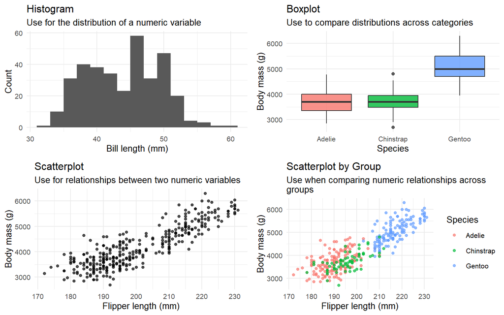

```r
library(gridExtra)

# histogram
p1 <- ggplot(penguins, aes(x = bill_length_mm)) +
  geom_histogram(binwidth = 2) +
  labs(
  title = "Histogram",
  subtitle = "Use for the distribution of a numeric variable",
  x = "Bill length (mm)",
  y = "Count"
  ) +
  theme_minimal(base_size = 10)


# boxplot
p2 <- ggplot(penguins, aes(x = species, y = body_mass_g, fill = species)) +
  geom_boxplot(alpha = 0.8) +
  labs(
  title = "Boxplot",
  subtitle = "Use to compare distributions across categories",
  x = "Species",
  y = "Body mass (g)"
  ) +
  theme_minimal(base_size = 10) +
  theme(legend.position = "none")

# scatterplot
p3 <- ggplot(penguins, aes(x = flipper_length_mm, y = body_mass_g)) +
  geom_point(alpha = 0.7) +
  labs(
  title = "Scatterplot",
  subtitle = "Use for relationships between two numeric variables",
  x = "Flipper length (mm)",
  y = "Body mass (g)"
  ) +
  theme_minimal(base_size = 10)

# another scatterplot
p4 <- ggplot(penguins, aes(x = flipper_length_mm, y = body_mass_g, color = species)) +
  geom_point(alpha = 0.7) +
  labs(
  title = "Scatterplot by Group",
  subtitle = "Use when comparing numeric relationships across \ngroups",
  x = "Flipper length (mm)",
  y = "Body mass (g)",
  color = "Species"
  ) +
  theme_minimal(base_size = 10)


grid.arrange(p1, p2, p3, p4, ncol = 2)
```

### Faceting

Another way to show groups is to split your plot into panels. An example:

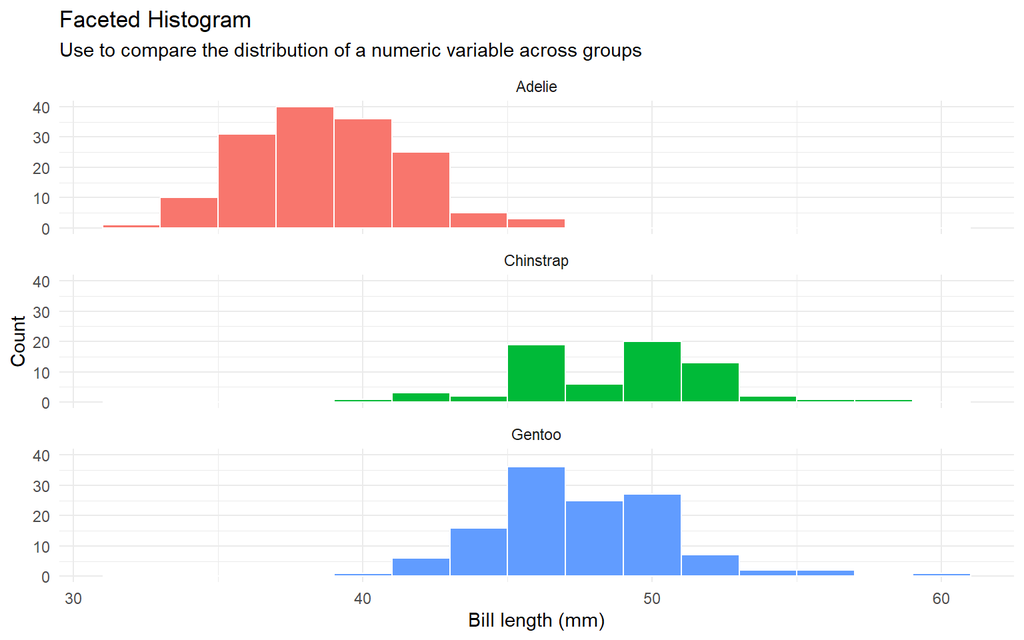

```r
ggplot(penguins, aes(x = bill_length_mm, fill = species)) +
  geom_histogram(binwidth = 2, color = "white") +
  labs(
    title = "Faceted Histogram",
    subtitle = "Use to compare the distribution of a numeric variable across groups",
    x = "Bill length (mm)",
    y = "Count"
  ) +
  facet_wrap(~ species, ncol = 1) +
  theme_minimal() +
  theme(legend.position = "none")
```

### Making plots standalone

A good plot should be understandable without reading surrounding text. Be mindful of labels, titles, legends, and captions.

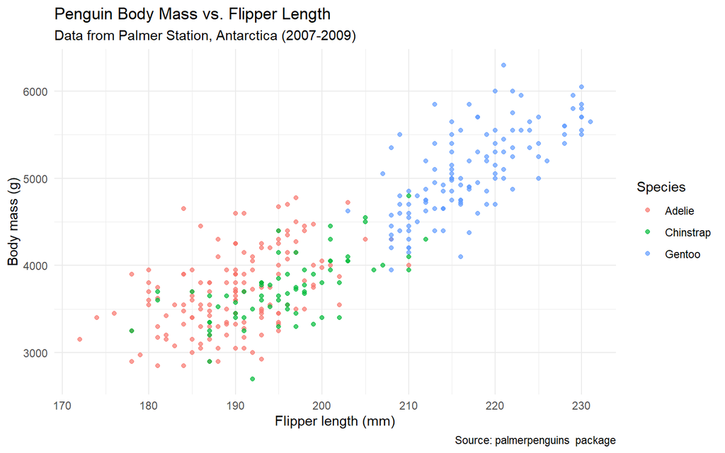

```r
ggplot(penguins, aes(x = flipper_length_mm, y = body_mass_g, color = species)) +
  geom_point(alpha = 0.7) +
  labs(
    title = "Penguin Body Mass vs. Flipper Length",
    subtitle = "Data from Palmer Station, Antarctica (2007-2009)",
    x = "Flipper length (mm)",
    y = "Body mass (g)",
    color = "Species",
    caption = "Source: palmerpenguins  package"
  ) +
  theme_minimal()
```

## Tables

Sometimes you need a table to show the information clearly.

```r
library(gt)

# summarize data
penguin_summary <- penguins |>
  group_by(species) |>
  summarize(
    mean_mass_g = round(mean(body_mass_g, na.rm = TRUE)),
    mean_flipper_mm = round(mean(flipper_length_mm, na.rm = TRUE)),
    n = n()
  )

# table
penguin_summary |>
  gt() |>
  tab_header(
    title = "Summary of Penguins",
  ) |>
  cols_label(
    species = "Species",
    mean_mass_g = "Mean Mass (g)",
    mean_flipper_mm = "Mean Flipper Length (mm)",
    n = "Count"
  ) |>
  tab_style(
    style = cell_fill(color = ),
    locations = cells_body(rows = species == "Adelie")
  )
```

Summary of Penguins

| Species | Mean Mass (g) | Mean Flipper Length (mm) | Count |
| --- | --- | --- | --- |
| Adelie | 3701 | 190 | 152 |
| Chinstrap | 3733 | 196 | 68 |
| Gentoo | 5076 | 217 | 124 |

## Modeling with broom and modelsummary

### Running models

```r
model <- lm(body_mass_g ~ flipper_length_mm + species, data = penguins)
summary(model)
```

```
##
## Call:
## lm(formula = body_mass_g ~ flipper_length_mm + species, data = penguins)
##
## Residuals:
##     Min      1Q  Median      3Q     Max
## -927.70 -254.82  -23.92  241.16 1191.68
##
## Coefficients:
##                    Estimate Std. Error t value Pr(>|t|)
## (Intercept)       -4031.477    584.151  -6.901 2.55e-11 ***
## flipper_length_mm    40.705      3.071  13.255  < 2e-16 ***
## speciesChinstrap   -206.510     57.731  -3.577 0.000398 ***
## speciesGentoo       266.810     95.264   2.801 0.005392 **
## ---
## Signif. codes:  0 '***' 0.001 '**' 0.01 '*' 0.05 '.' 0.1 ' ' 1
##
## Residual standard error: 375.5 on 338 degrees of freedom
##   (2 observations deleted due to missingness)
## Multiple R-squared:  0.7826, Adjusted R-squared:  0.7807
## F-statistic: 405.7 on 3 and 338 DF,  p-value: < 2.2e-16
```

### Tidying with broom

```r
library(broom)

# coefficients as a tidy data frame
tidy(model)
```

```
## # A tibble: 4 × 5
##   term              estimate std.error statistic  p.value
##   <chr>                <dbl>     <dbl>     <dbl>    <dbl>
## 1 (Intercept)        -4031.     584.       -6.90 2.55e-11
## 2 flipper_length_mm     40.7      3.07     13.3  1.40e-32
## 3 speciesChinstrap    -207.      57.7      -3.58 3.98e- 4
## 4 speciesGentoo        267.      95.3       2.80 5.39e- 3
```

```r
# model fit statistics
glance(model)
```

```
## # A tibble: 1 × 12
##   r.squared adj.r.squared sigma statistic   p.value    df logLik   AIC   BIC
##       <dbl>         <dbl> <dbl>     <dbl>     <dbl> <dbl>  <dbl> <dbl> <dbl>
## 1     0.783         0.781  376.      406. 1.25e-111     3 -2511. 5032. 5051.
## # ℹ 3 more variables: deviance <dbl>, df.residual <int>, nobs <int>
```

```r
# add fitted values and residuals to data
augment(model) |> head()
```

```
## # A tibble: 6 × 10
##   .rownames body_mass_g flipper_length_mm species .fitted .resid    .hat .sigma
##   <chr>           <int>             <int> <fct>     <dbl>  <dbl>   <dbl>  <dbl>
## 1 1                3750               181 Adelie    3336.  414.  0.0120    375.
## 2 2                3800               186 Adelie    3540.  260.  0.00767   376.
## 3 3                3250               195 Adelie    3906. -656.  0.00833   374.
## 4 5                3450               193 Adelie    3825. -375.  0.00724   376.
## 5 6                3650               190 Adelie    3703.  -52.5 0.00662   376.
## 6 7                3625               181 Adelie    3336.  289.  0.0120    376.
## # ℹ 2 more variables: .cooksd <dbl>, .std.resid <dbl>
```

### Presenting with modelsummary

```r
library(modelsummary)

# fit multiple models
m1 <- lm(body_mass_g ~ flipper_length_mm, data = penguins)
m2 <- lm(body_mass_g ~ flipper_length_mm + species, data = penguins)
m3 <- lm(body_mass_g ~ flipper_length_mm * species, data = penguins)

models <- list(
  "Flipper only" = m1,
  "+ Species" = m2,
  "Interaction" = m3
)

# regression table
modelsummary(
  models,
  gof_omit = "AIC|BIC|Log.Lik|RMSE",
  output = "gt"
) |>
  tab_options(table.align = "center")
```

|  | Flipper only | + Species | Interaction |
| --- | --- | --- | --- |
| (Intercept) | -5780.831 | -4031.477 | -2535.837 |
|  | (305.815) | (584.151) | (879.468) |
| flipper_length_mm | 49.686 | 40.705 | 32.832 |
|  | (1.518) | (3.071) | (4.627) |
| speciesChinstrap |  | -206.510 | -501.359 |
|  |  | (57.731) | (1523.459) |
| speciesGentoo |  | 266.810 | -4251.444 |
|  |  | (95.264) | (1427.332) |
| flipper_length_mm × speciesChinstrap |  |  | 1.742 |
|  |  |  | (7.856) |
| flipper_length_mm × speciesGentoo |  |  | 21.791 |
|  |  |  | (6.941) |
| Num.Obs. | 342 | 342 | 342 |
| R2 | 0.759 | 0.783 | 0.790 |
| R2 Adj. | 0.758 | 0.781 | 0.786 |

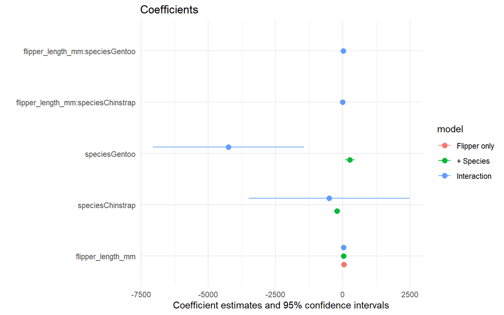

```r
# coefficients plot
modelplot(models, coef_omit = "Intercept") +
  theme_minimal() +
  labs(title = "Coefficients")
```

This script was drafted by [Killian Conyngham](https://github.com/Killian-Conyngham) and [Carol Sobral](https://github.com/cbsobral).